# QSS5.5.3課題

[佐藤 慧](https://keisato0.github.io/)

2020年7月17日

# はじめに

問題に取り組む前に，ライブラリとデータセットを読み込む

```r
library(tidyverse)
library(magrittr)
library(patchwork)

library(qss)
data(elections)
```

```r
elections %>% glimpse()
```

```
## Rows: 43,494
## Columns: 6
## $ year   <int> 1960, 1960, 1960, 1960, 1960, 1960, 1960, 1960, 1960, 1960, 1…
## $ state  <chr> "alabama", "alabama", "alabama", "alabama", "alabama", "alaba…
## $ county <chr> "autauga", "baldwin", "barbour", "bibb", "blount", "bullock",…
## $ rep    <int> 1149, 4812, 1166, 1052, 2557, 412, 1231, 4821, 1865, 872, 320…
## $ dem    <int> 1324, 5647, 2148, 1697, 3404, 757, 2872, 9590, 5165, 3097, 17…
## $ other  <int> 89, 187, 37, 4, 19, 6, 20, 218, 117, 9, 19, 97, 92, 23, 12, 2…
```

# 問題1：郡レベルでの投票傾向2008

## アリゾナ州

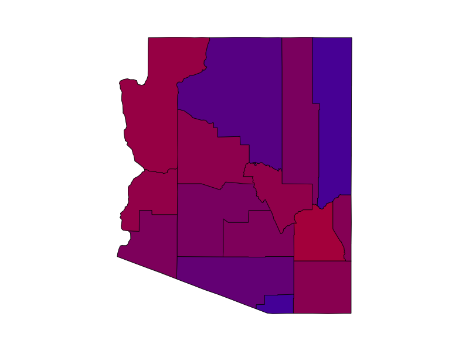

```r
# map()関数のregion引数を"state名,county名"形式で指定しないといけないので，
# dfにあらかじめ"state,county"形式の文字列ベクトルを追加しておく
elections %>%
  mutate(rep_ratio = rep / (rep + dem + other),
         dem_ratio = dem / (rep + dem + other),
         state_county = paste(state, county, sep = ",")) -> elections

elections %>% filter(year == 2008 & state == "arizona") -> arizona_2008

library(maps)

#描画----------------------------------------------------------------------
png(filename = "arizona2008.png", width = 800, height = 600)
map(database = "county", regions = "arizona")
for (i in 1:nrow(arizona_2008)) {
  county_name <- arizona_2008$county[i]
  map(database = "county", regions = paste("arizona", county_name, sep = ","),
      col = rgb(red = arizona_2008$rep_ratio[i],
                blue = arizona_2008$dem_ratio[i],
                green = 0),
      add = TRUE, fill = TRUE)
}
dev.off()
```

#### コメント

全般的に共和党支持が多いが，北東のアパッチ郡では民主党支持のほうがかなり多そうにみえる。この郡の人口の4分の3が先住民らしいので，そのことと強い関係があるように思われる。

## マサチューセッツ州

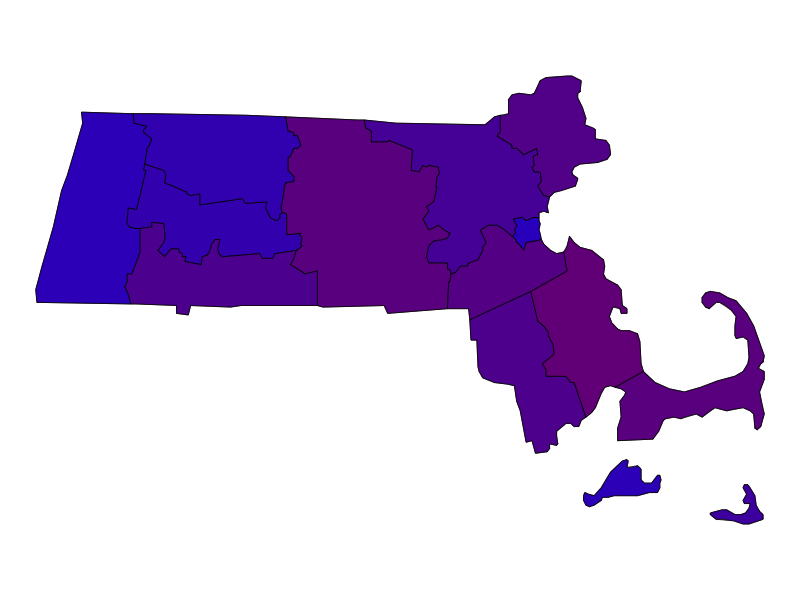

```r
elections %>% filter(year == 2008 & state == "massachusetts") -> massachusetts_2008

#描画----------------------------------------------------------------------
png(filename = "massachusetts2008.png", width = 800, height = 600)
map(database = "county", regions = "massachusetts")
for (i in 1:nrow(massachusetts_2008)) {
  county_name <- massachusetts_2008$county[i]
  map(database = "county", regions = paste("massachusetts", county_name, sep = ","),
      col = rgb(red = massachusetts_2008$rep_ratio[i],
                blue = massachusetts_2008$dem_ratio[i],
                green = 0),
      add = TRUE, fill = TRUE)
}
dev.off()
```

#### コメント

全般的に民主党支持が強いが，海岸沿いのほうが共和党支持の割合が高い。海岸沿いでも，ボストンのあるサフォーク郡は民主党支持が強いのが目を引く。大学関係者などリベラルな人がたくさんいるからだろう。

# 問題2：郡レベルでの投票傾向2008全国

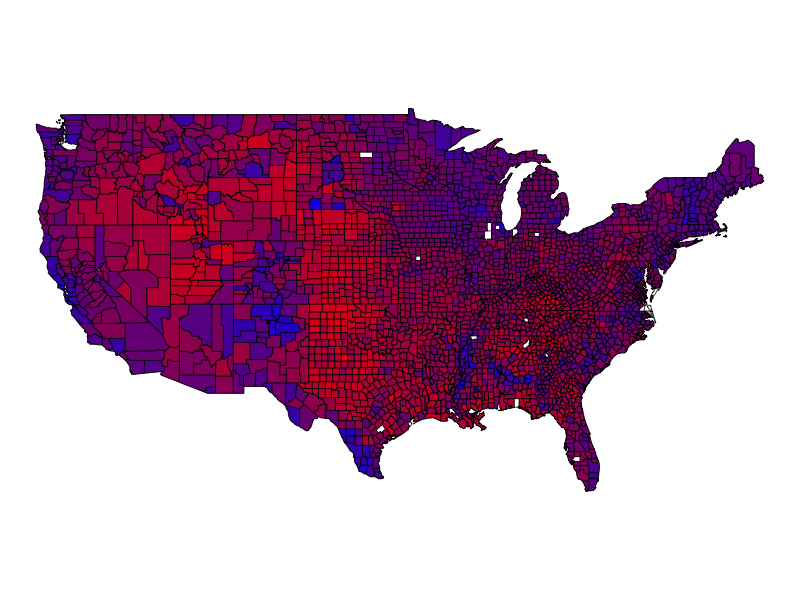

```r
elections %>%
  filter(year == 2008) -> elections_2008


# エラー回避 -------------------------------------------------------------------
# 先に下のループを回そうとしたがエラー
# map関数のデータベースに登録されている郡の数と，electionsデータセットに含まれる郡の数が違う
# 以下のように調整

# map()のデータベースに登録されている郡の文字列ベクトル
# 下のsemi_join()が使えるようにdf化
map_county_list <- map(database = "county", plot = FALSE)
map_county_list <- data.frame(state_county = map_county_list$names)

# nrow(map_county_list) は3085, nrow(elections_2008) は3108なので，
# map()のデータベースのほうが少なく，
# map()にある郡の名前があるレコードだけのdfをつくりなおす
semi_join(elections_2008, map_county_list,
          by = "state_county") -> elections_2008


# 描画 ----------------------------------------------------------------------
png("county2008.png", width = 800, height = 600)
map(database = "county")
for (i in 1:nrow(elections_2008)) {
  map(database = "county", regions = elections_2008$state_county[i],
      col = rgb(red = elections_2008$rep_ratio[i],
                blue = elections_2008$dem_ratio[i],
                green = 0),
      add = TRUE, fill = TRUE)
}
dev.off()
```

#### コメント

中西部一帯で共和党支持が非常に強く，民主党は海岸沿いにポツポツという感じで，この地図だけみるとなぜ民主党が共和党と互角の支持を得ているのか不思議に思われてくるが，海岸沿いの地方は面積では小さいものの人口は多いので，政権交代が定期的に起こる程度には民主党支持が強いのだと思われる。地図の中央下部，ニューメキシコ州の民主党支持が周りとは異なり強いのも目立つ。

# 問題3：アニメーション

## 画像をつくってみる

アニメ化の前に練習として，1960年から2012年までの結果を表示した画像をひとつひとつつくってみる。

```r
# dfをyearでリスト化(階層化)する------------------------------------------------------
elections %>%
  group_by(year) %>%
  group_split() -> elections_year_list

# 各yearのdfに同じ処理が加えられるようループ------------------------------------------
# まず，map()のデータベースにない郡のレコードを消した上で作業用dfをつくりなおす
for (i in 1:length(elections_year_list)) {
semi_join(elections_year_list[[i]], map_county_list,
          by = "state_county") -> tentative
# 描画--------------------------------------------------------------------------------
# 白いキャンバスを用意するところまでは外側のループで
png(filename = paste(as.character(1956 + i*4), "png", sep = "."),
    width = 800, height = 600)
map(database = "county")

# 各郡に色を塗っていく----------------------------------------------------------------
# 各yearのdfでループ
for (j in 1:nrow(tentative)) {
  map(database = "county", regions = tentative$state_county[j],
      col = rgb(red = tentative$rep_ratio[j],
                blue = tentative$dem_ratio[j],
                green = 0),
      add = TRUE, fill = TRUE)
}
title(as.character(1956 + i*4))
dev.off()
}
```

### いくつかの例

上が1960年，下が2012年。

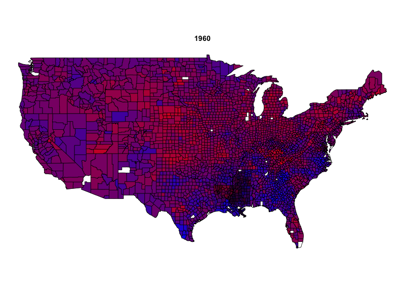

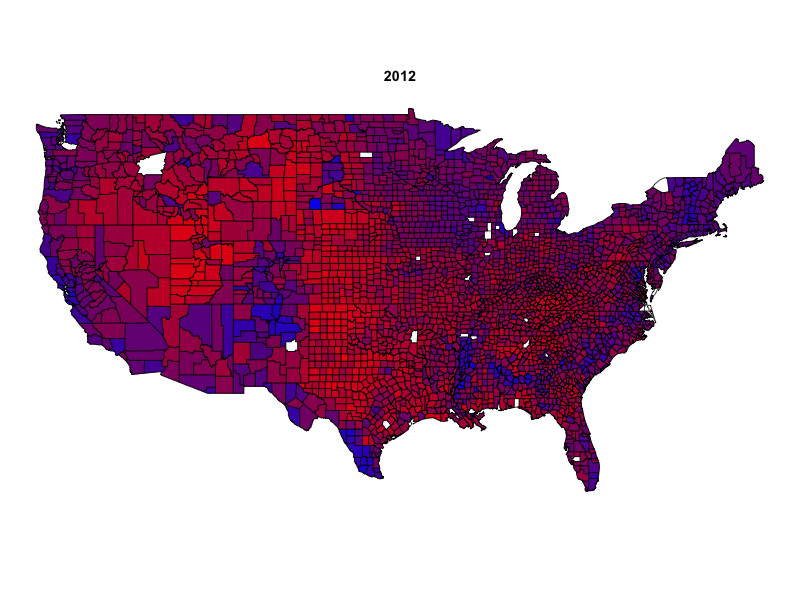

## アニメーションにする

```r
# saveHTML()の中は上と同じコード

library(animation)
saveHTML({
  for (i in 1:length(elections_year_list)) {
    semi_join(elections_year_list[[i]], map_county_list,
              by = "state_county") -> tentative

    map(database = "county")

    for (j in 1:nrow(tentative)) {
      map(database = "county", regions = tentative$state_county[j],
          col = rgb(red = tentative$rep_ratio[j],
                    blue = tentative$dem_ratio[j],
                    green = 0),
          add = TRUE, fill = TRUE)
    }
    title(as.character(1956 + i*4))
  }
}, autobrowse = FALSE, htmlfile = "elections.html",
title = "American Presidential Elections 1960-2012"
)
```

#### コメント

アニメは [こちらから見られます](https://keisato0.github.io/qss/chapter5/elections/elections.html)。一貫して民主党／共和党支持というところは意外と少ないことがわかる。また年により，紫(接戦)が多いときと，青/赤が全土で目立つ(圧勝・完敗)ときがある。

# 問題4：非類似度 2008

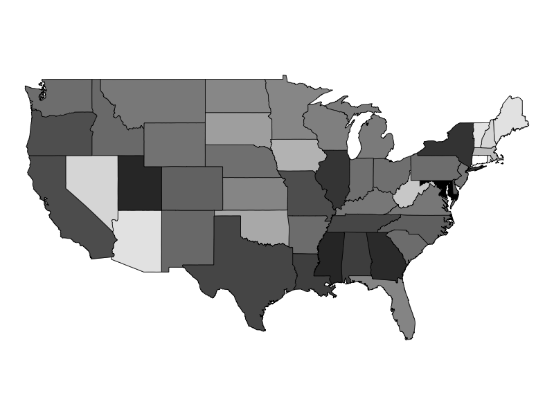

```r
# 州レベルでdfをリスト化する
elections_2008 %>%
  group_by(state) %>%
  group_split() -> elections_2008_list

# 結果を収納するdf(州名と値の二列)
data.frame(state = rep(NA, times = 48),
           dissimilarity = rep(NA, times = 48)
           ) -> dissimilarity

# 非類似度の計算
for (i in 1:48) {
  dissimilarity$state[i] <- unique(elections_2008_list[[i]]$state)

  dissimilarity$dissimilarity[i] <- elections_2008_list[[i]] %>%
    transmute(each_similarity = case_when(
      0 <= (dem / sum(dem)) - (rep / sum(rep)) ~
        (dem / sum(dem)) - (rep / sum(rep)),
      (dem / sum(dem)) - (rep / sum(rep)) < 0 ~
        -((dem / sum(dem)) - (rep / sum(rep)))
    )
    ) %>%
    sum() / 2
}

# View(dissimilarity)で確認
# ばらつきが小さいので最小値0，最大値1に標準化

dissimilarity %>%
  mutate(dissimilarity = (dissimilarity - min(dissimilarity)) /
           (max(dissimilarity) - min(dissimilarity))
         ) -> dissimilarity

# 描画
png(filename = "dissimilarity2008.png", width = 800, height = 600)
map(database = "state")
for (i in 1:48) {
  map(database = "state", regions = dissimilarity$state[i],
      fill = TRUE, add = TRUE,
      col = grey(1 - dissimilarity$dissimilarity[i])
  )
}
dev.off()
```

#### コメント

色が薄いほど非類似度が小さい。郡レベルでのばらつきが多いのは南東部に多いような印象を受ける。反対に中西部は比較的色が薄い。ランキングは以下のようになる(標準化前)。

| state | dissimilarity |
| --- | --- |
| maryland | 0.3258740 |
| mississippi | 0.2737492 |
| utah | 0.2719561 |
| georgia | 0.2670630 |
| new york | 0.2551592 |
| 略 | 略 |
| connecticut | 0.0519409 |
| vermont | 0.0763564 |
| rhode island | 0.0765076 |
| maine | 0.0774525 |
| arizona | 0.0775499 |

# 問題5：州ごとの民主党得票数ジニ係数2008

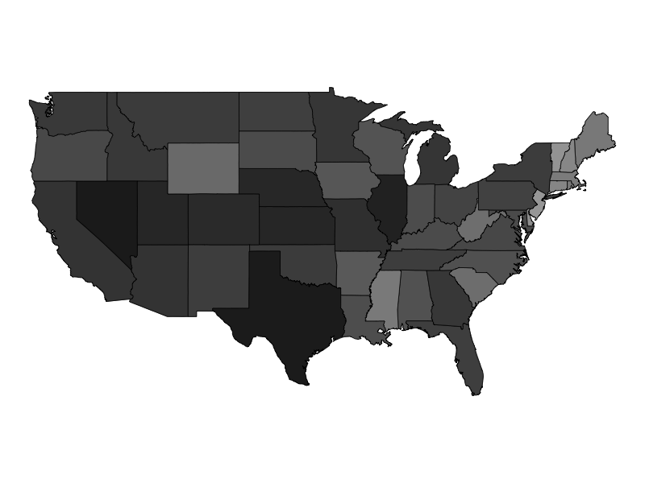

```r
# 結果収納用df
data.frame(state = rep(NA, times = 48),
           gini = rep(NA, times = 48)
) -> gini

# ジニ係数の計算
library(ineq)
for (i in 1:48) {
  gini$state[i] <- unique(elections_2008_list[[i]]$state)
  gini$gini[i] <- ineq(x = elections_2008_list[[i]]$dem, type = "Gini")
}

#View(gini)で確認，問題なし

# 描画
png(filename = "gini2008.png", width = 800, height = 600)
map(database = "state")
for (i in 1:48) {
  map(database = "state", regions = gini$state[i],
      fill = TRUE, add = TRUE,
      col = grey(1 - gini$gini[i])
      )
  }
dev.off()
```

# 問題6：非類似度とジニ係数の推移

## 非類似度

```r
# 州と年でリスト化
elections %>%
  group_by(state, year) %>%
  group_split() -> elections_list

# 結果収納用df(州，年の順にグループ化されるように設定)
data.frame(
  state = rep(unique(elections$state), each = 14),
  year = rep(seq(1960, 2012, by = 4), times = 48),
  dissimilarity = NA
) -> dissimilarity_all

# 非類似度の計算
for (i in 1:length(elections_list)) {
  dissimilarity_all$dissimilarity[i] <-
    elections_list[[i]] %>%
    transmute(each_similarity = case_when(
      0 <= (dem / sum(dem)) - (rep / sum(rep)) ~
        (dem / sum(dem)) - (rep / sum(rep)),
      (dem / sum(dem)) - (rep / sum(rep)) < 0 ~
        -((dem / sum(dem)) - (rep / sum(rep)))
    )) %>%
    sum() / 2
}

# View(dissimilarity_all)で確認
# アラバマ州1964年が全員共和党に入れたため上の計算ではNAとなり，これだけ手動で追加
dissimilarity_all$dissimilarity[2] <- 0.5

# 最小値0，最大値1に標準化
dissimilarity_all %>%
  mutate(dissimilarity = (dissimilarity - min(dissimilarity)) /
           (max(dissimilarity) - min(dissimilarity))
         ) -> dissimilarity_all


# 結果のdfを年ごとにリスト化
dissimilarity_all %>%
  group_by(year) %>%
  group_split() -> dissimilarity_all_list

# 描画
saveHTML({
for (i in 1:14) {
  map(database = "state")
  for (j in 1:48) {
    map(database = "state",
        regions = as.character(dissimilarity_all_list[[i]]$state[j]),
        fill = TRUE, add = TRUE,
        col = grey(1- dissimilarity_all_list[[i]]$dissimilarity[j])
    )
  }
  title(as.character(1956 + i*4))
}
  }, autobrowse = FALSE, htmlfile = "dissimilarity.html",
title = "Dissimilarity Index 1960-2012"
)
```

#### コメント

[アニメへのリンク](https://keisato0.github.io/qss/chapter5/dissimilarity/dissimilarity.html)。濃いほうが非類似度が高い。2000年以降全般的に非類似度が上がっている(州のなかでの投票先のばらつきが大きくなりはじめた)ことがわかる。

## 州ごとの民主党得票数ジニ係数

```r
# 結果収納用df(州，年の順にグループ化されるように設定)
data.frame(
  state = rep(unique(elections$state), each = 14),
  year = rep(seq(1960, 2012, by = 4), times = 48),
  gini = NA
) -> gini_all

# ジニ係数の計算
for (i in 1:length(elections_list)) {
  gini_all$gini[i] <-
    ineq(x = elections_list[[i]]$dem, type = "Gini")
}

# 全員共和党に入れた1964年アラバマ州は計算できず，手動で追加
gini_all$gini[2]　<- 1

# 結果dfを年でリスト化
gini_all %>%
  group_by(year) %>%
  group_split() -> gini_all_list

# 描画
saveHTML({
  for (i in 1:14) {
    map(database = "state")
    for (j in 1:48) {
      map(database = "state",
          regions = as.character(gini_all_list[[i]]$state[j]),
          fill = TRUE, add = TRUE,
          col = grey(1 - gini_all_list[[i]]$gini[j])
          )
    }
    title(as.character(1956 + i*4))
  }
}, autobrowse = FALSE, htmlfile = "gini_coefficients.html",
title = "Gini Coefficients 1960-2012"
)
```

#### コメント

[アニメへのリンク](https://keisato0.github.io/qss/chapter5/gini/gini_coefficients.html)。濃いほうがジニ係数が高い。こちらも2000年以降，全般的に高くなっている印象がある。